# Assignment2

## 9. Repeat thie procedure for $t=1,\cdots,10$

```r
df_T <- df %>%
  dplyr::mutate(nu = rnorm(1000, 0, sigma_nu))

df_last <- df_T
for (i in 1:9){
    df_inter <- expand.grid(j = 1:1000, t = i + 1) %>%
    tibble::as.tibble() %>%
    dplyr::mutate(k = log((1-delta) * exp(df_last$k) + df_last$I)) %>%
    dplyr::mutate(omega =  alpha * df_last$omega + df_last$nu) %>%
    dplyr::mutate(wage = 0.5 * rep(1, times = 1000) ) %>%
    dplyr::mutate(iota = rnorm(1000, mean = 0, sd = 0.05)) %>%
    dplyr::mutate(l = log_labor_choice(k, wage, omega,
                                     beta_0, beta_l, beta_k, sigma_eta)) %>%
    dplyr::mutate(l_error = log_labor_choice_error(k, wage, omega, beta_0,
                                                 beta_l, beta_k, iota, sigma_eta)) %>%
    dplyr::mutate(I = investment_choice(k, omega, gamma, delta)) %>%
    dplyr::mutate(eta = rnorm(1000, mean = 0, sd = sigma_eta)) %>%
    dplyr::mutate(y = log_production(l, k, omega, eta, beta_0, beta_l, beta_k)) %>%
    dplyr::mutate(y_error = log_production(l_error, k, omega, eta, beta_0, beta_l,             beta_k)) %>%
    dplyr::mutate(nu = rnorm(1000, 0, sigma_nu)) %>%
    dplyr::arrange(j,t)
    df_last <- df_inter
    df_T = bind_rows(df_T, df_inter)
}
df_T
```

```
## # A tibble: 10,000 x 13
##        j     t     k   omega  wage     iota      l l_error       I     eta
##    <int> <dbl> <dbl>   <dbl> <dbl>    <dbl>  <dbl>   <dbl>   <dbl>   <dbl>
##  1     1     1 0.687  0.795    0.5 -0.0443   1.72   1.67    0.257   0.148
##  2     2     1 1.09   0.779    0.5 -0.0961   2.06   1.94    0.381   0.0773
##  3     3     1 0.582 -0.610    0.5  0.0810  -0.123 -0.0218 -0.0196  0.259
##  4     4     1 1.80   0.148    0.5  0.0260   1.89   1.92    0.391  -0.161
##  5     5     1 1.16   0.0486   0.5 -0.00279  1.21   1.21    0.176  -0.321
##  6     6     1 0.590 -1.16     0.5  0.0348  -0.809 -0.766  -0.120   0.187
##  7     7     1 1.24   0.568    0.5  0.00268  1.93   1.93    0.370   0.361
##  8     8     1 1.37  -1.34     0.5 -0.0655  -0.346 -0.428  -0.330  -0.0113
##  9     9     1 1.29  -0.873    0.5 -0.106    0.165  0.0327 -0.135   0.377
## 10    10     1 0.847  0.699    0.5 -0.0104   1.74   1.73    0.280   0.316
## # ... with 9,990 more rows, and 3 more variables: y <dbl>, y_error <dbl>,
## #   nu <dbl>
```

## 10. Summary statistics

```r
summary_1 <- psych::describe(df_T)
summary_T <- summary_1[,c('n','mean','sd','min','max')]
print(summary_T, digits = 7)
```

```
##             n        mean          sd        min          max
## j       10000 500.5000000 288.6894251  1.0000000 1000.0000000
## t       10000   5.5000000   2.8724249  1.0000000   10.0000000
## k       10000   0.9797900   0.5838949 -1.2822534    3.2332312
## omega   10000  -0.0055826   0.7025102 -2.5894171    2.6281307
## wage    10000   0.5000000   0.0000000  0.5000000    0.5000000
## iota    10000  -0.0000696   0.0502883 -0.1841453    0.1715419
## l       10000   0.9799746   1.0965108 -3.3281023    4.9679634
## l_error 10000   0.9798876   1.0971595 -3.3765433    4.9520674
## I       10000   0.1793502   0.3006526 -1.2722627    3.2975332
## eta     10000   0.0015825   0.2001539 -0.7650371    0.7455922
## y       10000   1.8778479   1.1171035 -2.4680251    6.1228291
## y_error 10000   1.8778305   1.1169266 -2.4777133    6.1196499
## nu      10000   0.0010197   0.4997130 -2.1513907    1.8253882
```

```r
linearMod_1  <- lm(formula = y_error ~ l_error + k, data = df_T)
summary(linearMod_1)
```

```
##
## Call:
## lm(formula = y_error ~ l_error + k, data = df_T)
##
## Residuals:
##      Min       1Q   Median       3Q      Max
## -0.73002 -0.14117 -0.00071  0.13743  0.87983
##
## Coefficients:
##             Estimate Std. Error t value Pr(>|t|)
## (Intercept) 0.892542   0.004058 219.966   <2e-16 ***
## l_error     0.997913   0.002396 416.454   <2e-16 ***
## k           0.007599   0.004503   1.688   0.0915 .
## ---
## Signif. codes:  0 '***' 0.001 '**' 0.01 '*' 0.05 '.' 0.1 ' ' 1
##
## Residual standard error: 0.2068 on 9997 degrees of freedom
## Multiple R-squared:  0.9657, Adjusted R-squared:  0.9657
## F-statistic: 1.408e+05 on 2 and 9997 DF,  p-value: < 2.2e-16
```

## 2. Within transform of $y_{jt}$, $l_{jt}$ and $k_{jt}$

```r
df_T_within <- df_T %>%
  group_by(j) %>%
  dplyr::mutate(dl_error = l_error - mean(l_error)) %>%
  dplyr::mutate(dk = k - mean(k)) %>%
  dplyr::mutate(dy_error = y_error - mean(y_error)) %>%
  dplyr::ungroup()
linearMod_2  <- lm(formula = dy_error ~ dl_error + dk - 1, data = df_T_within)
summary(linearMod_2)
```

```
##
## Call:
## lm(formula = dy_error ~ dl_error + dk - 1, data = df_T_within)
##
## Residuals:
##      Min       1Q   Median       3Q      Max
## -0.72450 -0.13285 -0.00244  0.12931  0.77657
##
## Coefficients:
##            Estimate Std. Error t value Pr(>|t|)
## dl_error  0.9910916  0.0029548 335.413   <2e-16 ***
## dk       -0.0009029  0.0127539  -0.071    0.944
## ---
## Signif. codes:  0 '***' 0.001 '**' 0.01 '*' 0.05 '.' 0.1 ' ' 1
##
## Residual standard error: 0.1961 on 9998 degrees of freedom
## Multiple R-squared:  0.9184, Adjusted R-squared:  0.9184
## F-statistic: 5.629e+04 on 2 and 9998 DF,  p-value: < 2.2e-16
```

## 3. First stage of Olley-Pakes

```r
bandwidth_error <- np::npplregbw(formula = y_error~l_error + k + I|k+I,data = df_T)
```

[output not shown]

[output cut: 8 more lines]

[output not shown]

```r
OP_stage_1_error <- np::npplreg(bws = bandwidth_error)
summary(OP_stage_1_error)
```

```
##
## Partially Linear Model
## Regression data: 10000 training points, in 5 variable(s)
## With 3 linear parametric regressor(s), 2 nonparametric regressor(s)
##
##                     y(z)
## Bandwidth(s): 0.07355059 0.01435558
##
##                     x(z)
## Bandwidth(s): 0.03908594 0.01191551
##               0.01397428 3.74953039
##               0.83529394 0.00398329
##
##                   l_error        k        I
## Coefficient(s): 0.2485295 2.355523 5.345145
##
## Kernel Regression Estimator: Local-Constant
## Bandwidth Type: Fixed
##
## Residual standard error: 0.1934585
## R-squared: 0.970064
##
## Continuous Kernel Type: Second-Order Gaussian
## No. Continuous Explanatory Vars.: 2
```

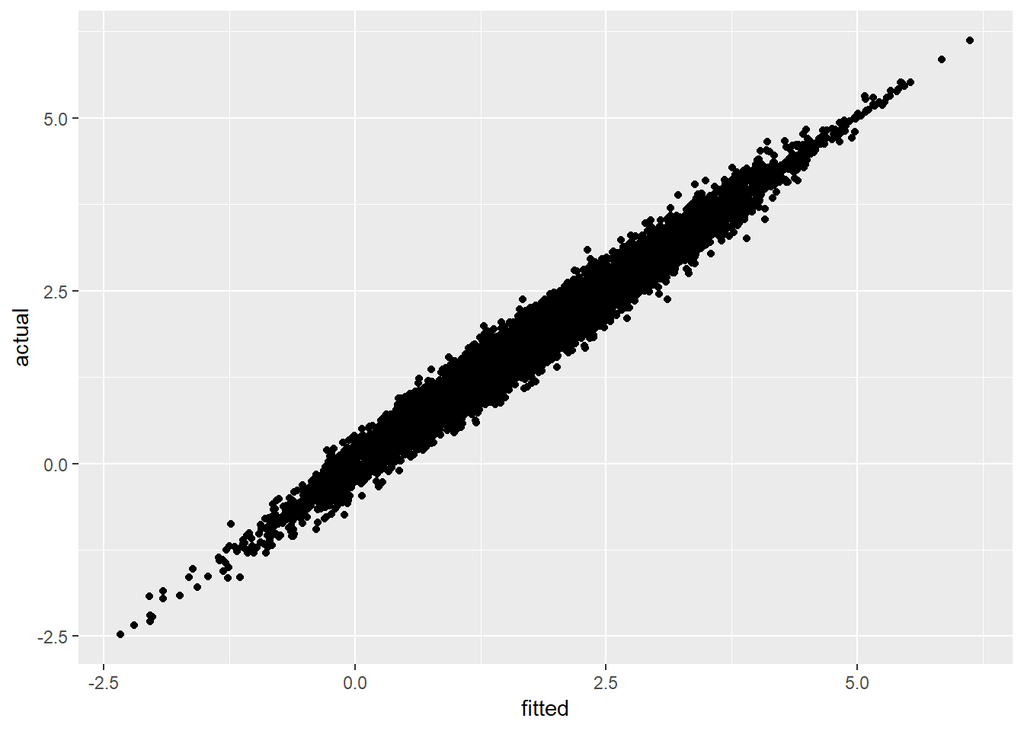

## 4 Check $\beta_l$ is not identified without optimization error

```r
bandwidth_1 <- np::npplregbw(formula = y~l + k + I|k+I,data = df_T)
```

[output not shown]

[output cut: 11 more lines]

[output not shown]

```r
OP_stage_1<- np::npplreg(bws = bandwidth_1)
summary(OP_stage_1)
```

```
##
## Partially Linear Model
## Regression data: 10000 training points, in 5 variable(s)
## With 3 linear parametric regressor(s), 2 nonparametric regressor(s)
##
##                     y(z)
## Bandwidth(s): 0.07347226 0.01437256
##
##                     x(z)
## Bandwidth(s): 0.02960021 0.009986945
##               0.01397428 3.749530394
##               0.83529394 0.003983290
##
##                        l        k         I
## Coefficient(s): 1.180628 2.034182 0.7805075
##
## Kernel Regression Estimator: Local-Constant
## Bandwidth Type: Fixed
##
## Residual standard error: 0.1932285
## R-squared: 0.970116
##
## Continuous Kernel Type: Second-Order Gaussian
## No. Continuous Explanatory Vars.: 2
```

## 5. Compute df_T_1st

```r
df_T_1st <- df_T[,c('j', 't', 'k', 'l_error', 'I', 'y_error')] %>%
dplyr::mutate(phi_t = y_error - coef(OP_stage_1_error)[1] * l_error
              - resid(OP_stage_1_error)) %>%
dplyr::arrange(j,t) %>%
group_by(j) %>%
dplyr::mutate(y_error_tilde = y_error - coef(OP_stage_1_error)[1] * l_error) %>%
dplyr::mutate(lag_l_error = lag(l_error)) %>%
dplyr::mutate(lag_k = lag(k)) %>%
dplyr::mutate(lag_I = lag(I)) %>%
dplyr::mutate(phi_t_1 = lag(phi_t))
df_T_1st[,c('j', 't', 'y_error_tilde', 'phi_t_1')]
```

```
## # A tibble: 10,000 x 4
## # Groups:   j [1,000]
##        j     t y_error_tilde phi_t_1
##    <int> <dbl>         <dbl>   <dbl>
##  1     1     1         2.34   NA
##  2     1     2         1.37    2.21
##  3     1     3         0.621   1.49
##  4     1     4         0.447   0.882
##  5     1     5         0.878   0.611
##  6     1     6         1.62    0.926
##  7     1     7         0.558   1.40
##  8     1     8         0.684   0.439
##  9     1     9         0.939   0.520
## 10     1    10         1.49    0.836
## # ... with 9,990 more rows
```

## 6. Moment condition function $g_{JT}(x,df_T_1st)$, where $x=(\alpha,\beta_0,\beta_k)$

```r
moment_OP_2nd(x = c(alpha, beta_0, beta_k), df_T_1st = df_T_1st)
```

```
##            k        lag_k        lag_I
## -0.012388147 -0.015068224  0.003483978
```

## 7. The GMM optimal function $Q_{JT}(x,df_T_1st),$ where $x=(\alpha,\beta_0,\beta_k)$

```r
object_OP_2nd(x = c(alpha, beta_0, beta_k), df_T_1st = df_T_1st)
```

```
##              [,1]
## [1,] 0.0003926557
```

## 8. Draw the objective function when one of the three parameters $\alpha, \beta_0$ and $\beta_k$ are changed from 0 to 1 by 0.1

Yes, the objective function is minimized around the true values of $\alpha, \beta_0$ and $\beta_k$

```r
alpha_seq <- seq(0, 1, 0.1)
output <-
  foreach (alpha_input = alpha_seq,
           .combine ="rbind") %do% {
             l <- object_OP_2nd(x = c(alpha_input, beta_0, beta_k),
                                df_T_1st = df_T_1st)
             return(l)
           }
```

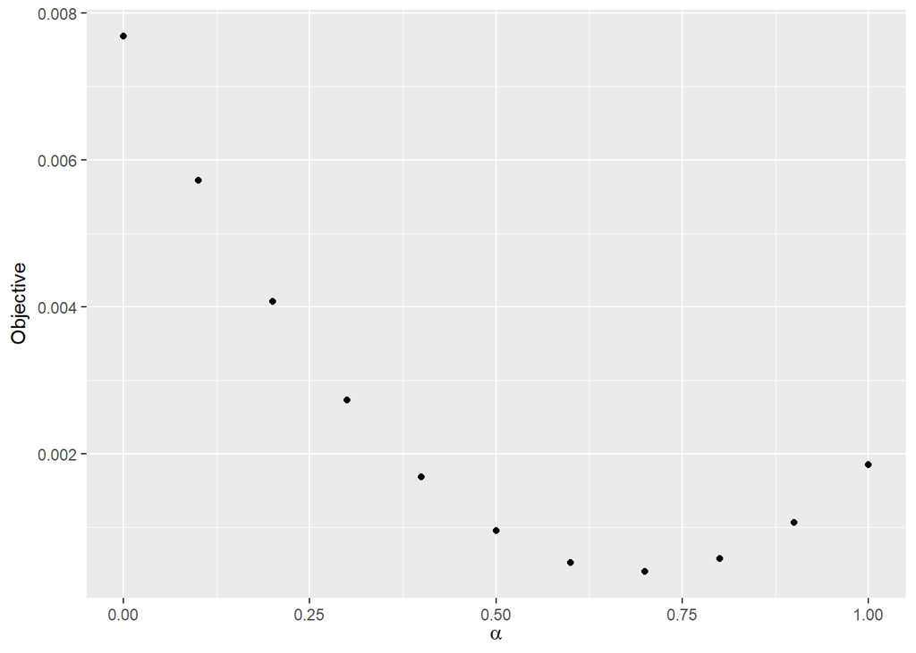

```r
beta_0_seq <- seq(0, 1, 0.1)
output_beta_0 <-
  foreach (beta_0_input = beta_0_seq,
           .combine ="rbind") %do% {
             l <- object_OP_2nd(c(alpha, beta_0_input, beta_k),
                                df_T_1st = df_T_1st)
             return(l)
           }
```

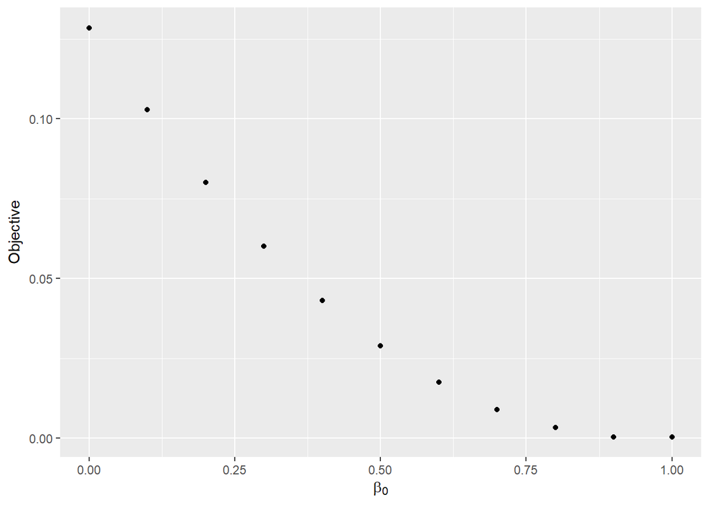

```r
beta_k_seq <- seq(0, 1, 0.1)
output_beta_k <-
  foreach (beta_k_input = beta_k_seq,
           .combine ="rbind") %do% {
             l <- object_OP_2nd(c(alpha, beta_0, beta_k_input),
                                df_T_1st = df_T_1st)
             return(l)
           }
```

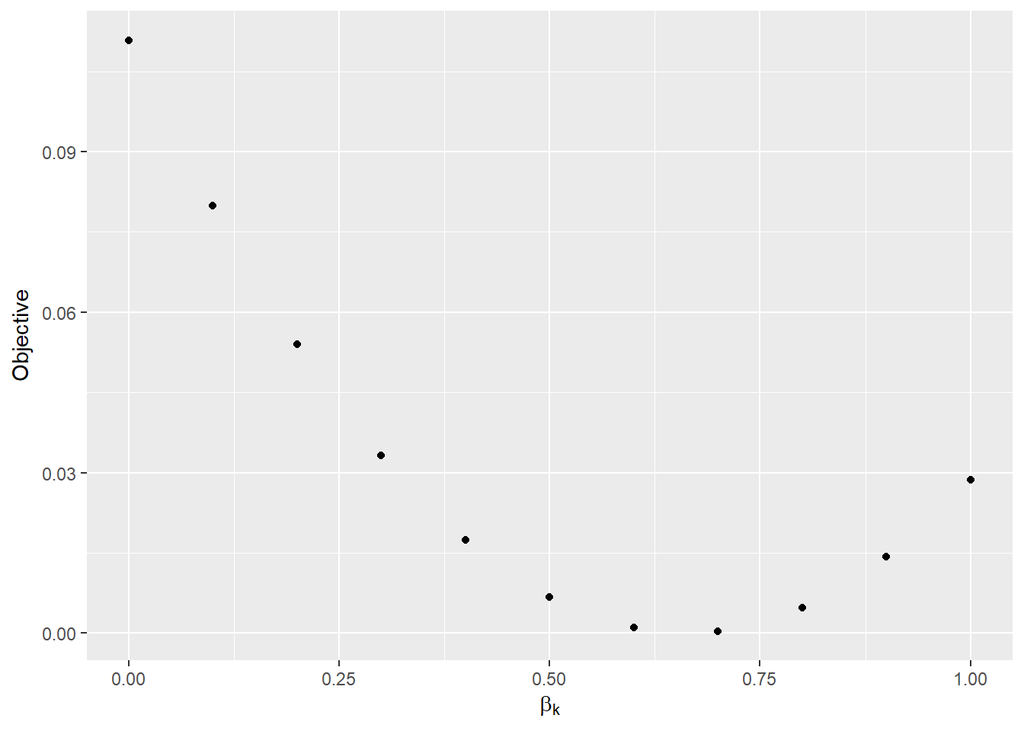

## 9. Find the parameters that minimize the objective function

```r
optim(par = c(0.7, 1, 0.7), fn = object_OP_2nd,
      df_T_1st = df_T_1st, method = 'L-BFGS-B')
```

```
## $par
## [1] 0.7561092 0.9728113 0.6681111
##
## $value
## [1] 1.935529e-07
##
## $counts
## function gradient
##        9        9
##
## $convergence
## [1] 0
##
## $message
## [1] "CONVERGENCE: REL_REDUCTION_OF_F <= FACTR*EPSMCH"
```